# Univariate: Parkinson

Jose Tamez

2023-02-02

# 1 PARKINSON Univariate

### 1.0.1 Loading the libraries

```r
library("FRESA.CAD")
library(readxl)
op <- par(no.readonly = TRUE)
pander::panderOptions('digits', 3)
pander::panderOptions('table.split.table', 400)
pander::panderOptions('keep.trailing.zeros',TRUE)
```

## 1.1 The Data

```r
pd_speech_features <- as.data.frame(read_excel("~/GitHub/FCA/Data/pd_speech_features.xlsx",sheet = "pd_speech_features", range = "A2:ACB758"))
```

### 1.1.1 The Average of the Three Repetitions

Each subject had three repeated observations. Here I’ll use the average of the three experiments per subject.

```r
rep1Parkison <- subset(pd_speech_features,RID==1)
rownames(rep1Parkison) <- rep1Parkison$id
rep1Parkison$id <- NULL
rep1Parkison$RID <- NULL
rep1Parkison[,1:ncol(rep1Parkison)] <- sapply(rep1Parkison,as.numeric)

rep2Parkison <- subset(pd_speech_features,RID==2)
rownames(rep2Parkison) <- rep2Parkison$id
rep2Parkison$id <- NULL
rep2Parkison$RID <- NULL
rep2Parkison[,1:ncol(rep2Parkison)] <- sapply(rep2Parkison,as.numeric)

rep3Parkison <- subset(pd_speech_features,RID==3)
rownames(rep3Parkison) <- rep3Parkison$id
rep3Parkison$id <- NULL
rep3Parkison$RID <- NULL
rep3Parkison[,1:ncol(rep3Parkison)] <- sapply(rep3Parkison,as.numeric)

whof <- !(colnames(rep1Parkison) %in% c("gender","class"));
avgParkison <- rep1Parkison;
avgParkison[,whof] <- (rep1Parkison[,whof] + rep2Parkison[,whof] + rep3Parkison[,whof])/3

pander::pander(table(avgParkison$class))
```

| 0 | 1 |
| --- | --- |
| 64 | 188 |

#### 1.1.1.1 Standarize the names for the reporting

```r
dataframe <- avgParkison
outcome <- "class"
```

```r
pander::pander(c(rows=nrow(dataframe),col=ncol(dataframe)-1))
```

| rows | col |
| --- | --- |
| 252 | 753 |

```r
pander::pander(table(dataframe[,outcome]))
```

| 0 | 1 |
| --- | --- |
| 64 | 188 |

```r
varlist <- colnames(dataframe)
varlist <- varlist[varlist != outcome]
varlist <- as.data.frame(cbind(name=varlist,desc=varlist))
```

## 1.2 Univariate

```r
univariate_columns <- c("caseMean","caseStd","controlMean","controlStd","controlKSP","ROCAUC","WilcoxRes.p","FRes.p")
univar <- uniRankVar(varlist,
               paste(outcome,"~1"),
               outcome,
               dataframe,
               categorizationType = "Raw",
               type = "LOGIT",
               rankingTest = "AUC",
                cateGroups = c(0.1, 0.9),
                raw.dataFrame = NULL,
                description = ".",
                uniType = "Binary")
```

100 : std_MFCC_1st_coef 200 : app_entropy_shannon_10_coef 300 : app_LT_entropy_log_9_coef 400 : tqwt_entropy_log_dec_7 500 : tqwt_TKEO_std_dec_35  
600 : tqwt_stdValue_dec_27 700 : tqwt_skewnessValue_dec_19

```r
pander::pander(univar$orderframe[1:20,univariate_columns])
```

|  | caseMean | caseStd | controlMean | controlStd | controlKSP | ROCAUC | WilcoxRes.p | FRes.p |
| --- | --- | --- | --- | --- | --- | --- | --- | --- |
| **std_delta_delta_log_energy** | 1.56e-02 | 8.19e-03 | 8.83e-03 | 4.35e-03 | 0.151717 | 0.798 | 2.93e-11 | 4.44e-16 |
| **std_delta_log_energy** | 4.20e-02 | 2.76e-02 | 2.43e-02 | 1.23e-02 | 0.172528 | 0.794 | 5.93e-11 | 2.89e-15 |
| **std_9th_delta_delta** | 1.89e-02 | 4.69e-03 | 1.46e-02 | 2.48e-03 | 0.448029 | 0.787 | 1.72e-10 | 1.26e-13 |
| **std_8th_delta_delta** | 1.94e-02 | 4.73e-03 | 1.51e-02 | 2.23e-03 | 0.908376 | 0.780 | 1.39e-09 | 2.39e-12 |
| **std_7th_delta_delta** | 2.10e-02 | 5.62e-03 | 1.60e-02 | 2.94e-03 | 0.830363 | 0.776 | 4.53e-10 | 1.26e-12 |
| **tqwt_entropy_log_dec_12** | -1.68e+05 | 3.86e+04 | -1.32e+05 | 3.25e+04 | 0.361893 | 0.770 | 3.44e-11 | 3.09e-13 |
| **std_6th_delta_delta** | 2.25e-02 | 6.42e-03 | 1.71e-02 | 2.97e-03 | 0.549789 | 0.768 | 3.41e-09 | 1.09e-11 |
| **std_8th_delta** | 4.09e-02 | 1.02e-02 | 3.20e-02 | 5.14e-03 | 0.960141 | 0.767 | 1.08e-08 | 1.04e-11 |
| **std_9th_delta** | 3.94e-02 | 1.01e-02 | 3.08e-02 | 5.80e-03 | 0.117295 | 0.764 | 7.85e-09 | 9.93e-12 |
| **tqwt_entropy_shannon_dec_12** | 6.13e+01 | 1.43e+02 | 2.18e+02 | 2.52e+02 | 0.013604 | 0.763 | 7.98e-17 | 3.78e-11 |
| **tqwt_stdValue_dec_12** | 1.81e-02 | 2.10e-02 | 4.45e-02 | 3.45e-02 | 0.292343 | 0.763 | 9.69e-16 | 3.45e-13 |
| **std_7th_delta** | 4.41e-02 | 1.21e-02 | 3.41e-02 | 6.99e-03 | 0.748746 | 0.760 | 4.85e-09 | 1.88e-11 |
| **tqwt_TKEO_mean_dec_12** | 8.95e-04 | 3.49e-03 | 4.06e-03 | 5.98e-03 | 0.000563 | 0.760 | 1.56e-18 | 5.80e-10 |
| **std_10th_delta_delta** | 1.86e-02 | 4.91e-03 | 1.46e-02 | 2.62e-03 | 0.920800 | 0.759 | 6.88e-09 | 9.10e-11 |
| **tqwt_TKEO_std_dec_12** | 1.00e-03 | 2.51e-03 | 4.21e-03 | 5.24e-03 | 0.001059 | 0.759 | 1.00e-17 | 3.60e-12 |
| **tqwt_entropy_log_dec_13** | -1.14e+05 | 3.17e+04 | -8.82e+04 | 2.42e+04 | 0.265432 | 0.757 | 3.04e-09 | 8.77e-11 |
| **std_11th_delta_delta** | 1.73e-02 | 4.04e-03 | 1.40e-02 | 2.21e-03 | 0.963577 | 0.757 | 6.64e-09 | 2.24e-10 |
| **tqwt_stdValue_dec_13** | 4.35e-02 | 4.32e-02 | 8.75e-02 | 5.82e-02 | 0.650816 | 0.755 | 4.71e-13 | 1.61e-10 |
| **tqwt_entropy_log_dec_11** | -2.21e+05 | 4.22e+04 | -1.86e+05 | 3.69e+04 | 0.321073 | 0.754 | 9.01e-10 | 3.73e-11 |
| **tqwt_entropy_shannon_dec_13** | 1.86e+02 | 2.84e+02 | 4.74e+02 | 4.39e+02 | 0.140805 | 0.754 | 4.68e-14 | 2.16e-09 |

```r
topfiveOrg <- rownames(univar$orderframe[1:5,])
```

## 1.3 Decorrelation Analysis

```r
DEdataframe <- GDSTMDecorrelation(dataframe,thr=0.80,verbose = TRUE)
```

Included: 717 , Uni p: 0.01155156 , Uncorrelated Base: 207 , Outcome-Driven Size: 0 , Base Size: 207

1 <R=1.000,w= 1,N= 291>, Top: 95( 3 )1 : 95 : 0.975,<|>Tot Used: 272 , Added: 178 , Zero Std: 0 , Max Cor: 1.000

2 <R=1.000,w= 1,N= 291>, Top: 15( 2 )1 : 15 : 0.975,<|>Tot Used: 282 , Added: 29 , Zero Std: 0 , Max Cor: 0.975

3 <R=0.975,w= 2,N= 227>, Top: 85( 2 )1 : 85 : 0.937,<|>Tot Used: 399 , Added: 113 , Zero Std: 0 , Max Cor: 0.991

4 <R=0.991,w= 2,N= 227>, Top: 9( 1 )1 : 9 : 0.946,<|>Tot Used: 403 , Added: 13 , Zero Std: 0 , Max Cor: 0.941

5 <R=0.941,w= 3,N= 249>, Top: 82( 4 )1 : 82 : 0.871,<|>Tot Used: 501 , Added: 124 , Zero Std: 0 , Max Cor: 0.990

6 <R=0.990,w= 3,N= 249>, Top: 12( 1 )1 : 12 : 0.895,<|>Tot Used: 509 , Added: 14 , Zero Std: 0 , Max Cor: 0.894

7 <R=0.894,w= 4,N= 183>, Top: 66( 3 )1 : 66 : 0.827,<|>Tot Used: 546 , Added: 83 , Zero Std: 0 , Max Cor: 0.942

8 <R=0.942,w= 4,N= 183>, Top: 12( 2 )1 : 12 : 0.821,<|>Tot Used: 551 , Added: 15 , Zero Std: 0 , Max Cor: 0.826

9 <R=0.826,w= 5,N= 20>, Top: 9( 1 )1 : 9 : 0.800,<|>Tot Used: 551 , Added: 10 , Zero Std: 0 , Max Cor: 0.945

10 <R=0.945,w= 5,N= 20>, Top: 1( 1 )1 : 1 : 0.800,<|>Tot Used: 551 , Added: 1 , Zero Std: 0 , Max Cor: 0.799

11 <R=0.000,w= 6,N= 0>

[ 11 ], 0.799405 Decor Dimension: 551 . Cor to Base: 286 , ABase: 55 , Outcome Base: 0

```r
pander::pander(c(Decorrleated_Fraction=sum(str_detect(colnames(DEdataframe),"La_"))/(ncol(DEdataframe)-1)))
```

| Decorrleated_Fraction |
| --- |
| 0.612 |

```r
pander::pander(c(Base_Fraction=sum(str_detect(colnames(DEdataframe),"Ba_"))/(ncol(DEdataframe)-1)))
```

| Base_Fraction |
| --- |
| 0 |

```r
demat <- attr(DEdataframe,"GDSTM")
pander::pander(c(sparse_Fraction=1.0-sum(demat==0)/ncol(demat)/nrow(demat)))
```

| sparse_Fraction |
| --- |
| 0.00386 |

```r
varlistDe <-  colnames(DEdataframe)[colnames(DEdataframe) != "class"];
varlistDe <- as.data.frame(cbind(name=varlistDe,desc=varlistDe))
```

### 1.3.1 The heat maps.

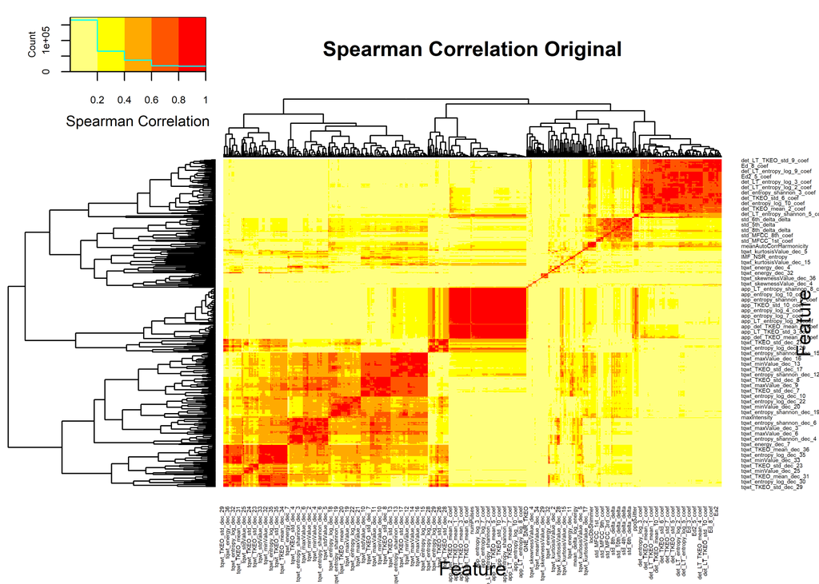

```r
par(cex=0.6,cex.main=0.85,cex.axis=0.7)
cormat <- cor(dataframe[,rownames(demat)],method="spearman")
cormat[is.na(cormat)] <- 0
gplots::heatmap.2(abs(cormat),
                  trace = "none",
#                  scale = "row",
                  mar = c(5,5),
                  col=rev(heat.colors(5)),
                  main = "Spearman Correlation Original",
                  cexRow = 0.35,
                  cexCol = 0.35,
                  key.title=NA,
                  key.xlab="Spearman Correlation",
                  xlab="Feature", ylab="Feature")
```

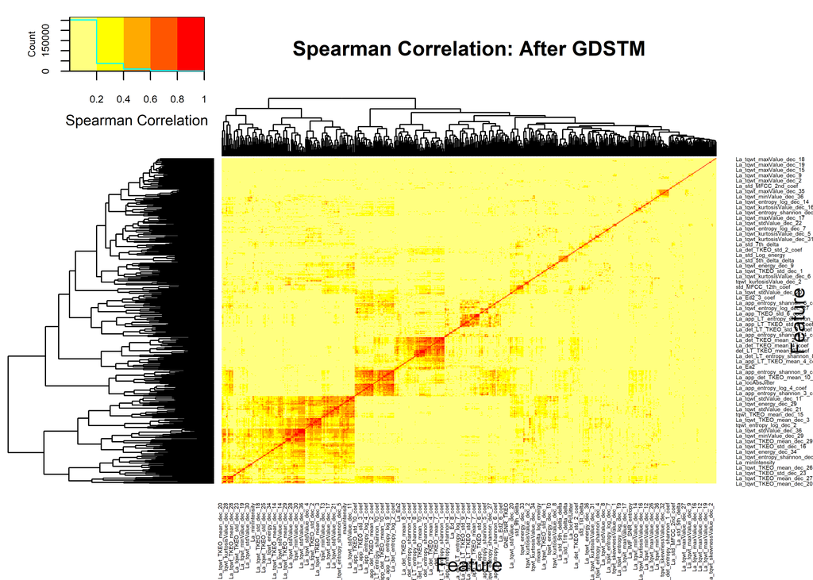

```r
cormat <- cor(DEdataframe[,colnames(demat)],method="spearman")
cormat[is.na(cormat)] <- 0
gplots::heatmap.2(abs(cormat),
                  trace = "none",
#                  scale = "none",
                  mar = c(5,5),
                  col=rev(heat.colors(5)),
                  main = "Spearman Correlation: After GDSTM",
                  cexRow = 0.35,
                  cexCol = 0.35,
                  key.title=NA,
                  key.xlab="Spearman Correlation",
                  xlab="Feature", ylab="Feature")
```

```r
par(op)
```

## 1.4 Univariate Decorrelated

```r
univarDe <- uniRankVar(varlistDe,
              paste(outcome,"~1"),
                outcome,
              DEdataframe,
                categorizationType = "Raw",
                type = "LOGIT",
                rankingTest = "AUC",
                cateGroups = c(0.1, 0.9),
                raw.dataFrame = NULL,
                description = ".",
                uniType = "Binary")
```

100 : La_std_MFCC_1st_coef 200 : La_app_entropy_shannon_10_coef 300 : La_app_LT_entropy_log_9_coef 400 : La_tqwt_entropy_log_dec_7 500 : La_tqwt_TKEO_std_dec_35  
600 : La_tqwt_stdValue_dec_27 700 : tqwt_skewnessValue_dec_19

```r
pander::pander(univarDe$orderframe[1:20,univariate_columns])
```

|  | caseMean | caseStd | controlMean | controlStd | controlKSP | ROCAUC | WilcoxRes.p | FRes.p |
| --- | --- | --- | --- | --- | --- | --- | --- | --- |
| **std_delta_log_energy** | 4.20e-02 | 2.76e-02 | 2.43e-02 | 1.23e-02 | 1.73e-01 | 0.794 | 5.93e-11 | 2.89e-15 |
| **La_tqwt_entropy_log_dec_33** | -2.53e+02 | 2.32e+02 | 6.61e+01 | 3.72e+02 | 5.55e-01 | 0.792 | 9.17e-16 | 0.00e+00 |
| **std_9th_delta** | 3.94e-02 | 1.01e-02 | 3.08e-02 | 5.80e-03 | 1.17e-01 | 0.764 | 7.85e-09 | 9.93e-12 |
| **mean_MFCC_2nd_coef** | 1.65e+00 | 1.37e+00 | 1.27e-01 | 1.71e+00 | 9.59e-01 | 0.753 | 5.17e-11 | 5.16e-14 |
| **La_tqwt_kurtosisValue_dec_33** | 2.42e+00 | 3.33e+00 | -3.33e-01 | 4.52e+00 | 9.49e-03 | 0.749 | 3.03e-10 | 1.10e-11 |
| **tqwt_minValue_dec_13** | -1.60e-01 | 1.26e-01 | -2.92e-01 | 1.68e-01 | 6.80e-01 | 0.746 | 1.11e-12 | 8.76e-11 |
| **La_std_delta_delta_log_energy** | 3.48e-03 | 3.09e-03 | 1.84e-03 | 1.64e-03 | 8.73e-02 | 0.744 | 1.99e-07 | 2.28e-06 |
| **La_apq11Shimmer** | 1.38e-02 | 1.45e-02 | 4.49e-03 | 9.78e-03 | 3.25e-02 | 0.731 | 4.41e-07 | 6.24e-08 |
| **tqwt_kurtosisValue_dec_20** | 2.55e+00 | 7.90e-01 | 2.09e+00 | 4.00e-01 | 2.44e-01 | 0.727 | 5.86e-07 | 6.25e-09 |
| **La_std_6th_delta** | 9.37e-03 | 7.37e-03 | 5.06e-03 | 3.64e-03 | 7.46e-01 | 0.726 | 2.39e-07 | 3.34e-05 |
| **tqwt_energy_dec_26** | 7.22e-02 | 8.33e-02 | 2.92e-02 | 5.56e-02 | 1.34e-05 | 0.726 | 9.12e-05 | 5.30e-06 |
| **tqwt_energy_dec_27** | 5.24e-02 | 9.45e-02 | 1.30e-02 | 3.57e-02 | 7.68e-08 | 0.725 | 3.58e-03 | 1.52e-04 |
| **La_tqwt_entropy_shannon_dec_33** | -5.89e-01 | 1.60e+00 | 6.74e-01 | 3.68e+00 | 3.36e-06 | 0.720 | 7.00e-07 | 4.49e-06 |
| **tqwt_energy_dec_12** | 3.68e-03 | 7.60e-03 | 1.27e-02 | 1.66e-02 | 2.80e-03 | 0.717 | 4.38e-15 | 2.09e-09 |
| **La_GNE_std** | -7.89e-02 | 6.02e-02 | -1.27e-01 | 6.85e-02 | 9.30e-01 | 0.714 | 6.01e-09 | 3.99e-09 |
| **tqwt_entropy_log_dec_10** | -2.63e+05 | 5.18e+04 | -2.29e+05 | 3.92e+04 | 2.37e-01 | 0.713 | 1.87e-06 | 2.15e-07 |
| **rapJitter** | 7.04e-04 | 9.87e-04 | 3.14e-04 | 3.46e-04 | 6.25e-03 | 0.711 | 4.63e-04 | 3.73e-06 |
| **DFA** | 7.13e-01 | 6.33e-02 | 6.64e-01 | 6.16e-02 | 8.65e-01 | 0.711 | 4.83e-07 | 3.82e-08 |
| **tqwt_entropy_shannon_dec_17** | 5.94e+02 | 4.67e+02 | 9.44e+02 | 4.14e+02 | 2.96e-01 | 0.709 | 6.78e-06 | 1.77e-07 |
| **tqwt_energy_dec_28** | 2.28e-02 | 5.50e-02 | 6.13e-03 | 2.34e-02 | 6.81e-11 | 0.709 | 3.51e-01 | 5.47e-03 |

### 1.4.1 Comparing Decorrelation vs Original

```r
pthr <- 0.20/(ncol(dataframe)-1)

topDecorNames <- rownames(univarDe$orderframe[univarDe$orderframe$FRes.p<pthr,])
topDecorNames <- unique(c(topDecorNames,rownames(univarDe$orderframe[1:5,])))

#topDecorNames <- rownames(univarDe$orderframe[univarDe$orderframe$FRes.p<1.0e-5,])
dc <- getLatentCoefficients(DEdataframe)
### 2a Get only the ones that in the top features
deNames_in_dc <- topDecorNames[topDecorNames %in% names(dc)]
selectedlist <- dc[deNames_in_dc]
theDeFormulas <- selectedlist

rawuniv <- univariate_Wilcoxon(dataframe,outcome,limit=-1)
deuniv <- univariate_Wilcoxon(DEdataframe,outcome,limit=-1)
matsize <- (ncol(dataframe)-1)^2
nocorrelated <- ncol(dataframe) - 1 - ncol(demat)
pander::pander(c(sparse_Fraction=(sum(demat != 0) + nocorrelated)/matsize))
```

| sparse_Fraction |
| --- |
| 0.00243 |

```r
pander::pander(c(raw=length(rawuniv),decor=length(deuniv)))
```

| raw | decor |
| --- | --- |
| 505 | 382 |

```r
pander::pander(c(Number_Latent=length(dc)))
```

| Number_Latent |
| --- |
| 461 |

```r
pander::pander(c(meanSize=mean(sapply(dc,length))))
```

| meanSize |
| --- |
| 2.35 |

## 1.5 CV ROC Analysis

```r
par(op)
par(mfrow=c(1,2),cex=0.9)
fraction <-0.70
repetitions <- 100

fcout <- round(fraction*nrow(dataframe)/15+1.0)
pander::pander(c(NumberofFeatures=fcout))
```

| NumberofFeatures |
| --- |
| 13 |

```r
cvRaw <- randomCV(dataframe,
                outcome,
                fittingFunction= filteredFit,
                classSamplingType = "Pro",
                trainFraction = fraction,
                repetitions = repetitions,
#                fitmethod=  glm,
                fitmethod=  KNN_method,
                filtermethod=mRMR.classic_FRESA,
                filtermethod.control=list(feature_count= fcout),
#                family="binomial"
)
```

……….10 Tested: 246 Avg. Selected: 13 Min Tests: 1 Max Tests: 8 Mean Tests: 3.130081 . MAD: 0.2483845

……….20 Tested: 252 Avg. Selected: 13 Min Tests: 2 Max Tests: 12 Mean Tests: 6.111111 . MAD: 0.2505551

……….30 Tested: 252 Avg. Selected: 13 Min Tests: 3 Max Tests: 18 Mean Tests: 9.166667 . MAD: 0.2445728

……….40 Tested: 252 Avg. Selected: 13 Min Tests: 3 Max Tests: 22 Mean Tests: 12.22222 . MAD: 0.2415974

……….50 Tested: 252 Avg. Selected: 13 Min Tests: 7 Max Tests: 26 Mean Tests: 15.27778 . MAD: 0.2418281

……….60 Tested: 252 Avg. Selected: 13 Min Tests: 9 Max Tests: 31 Mean Tests: 18.33333 . MAD: 0.2422674

……….70 Tested: 252 Avg. Selected: 13 Min Tests: 10 Max Tests: 35 Mean Tests: 21.38889 . MAD: 0.2430556

……….80 Tested: 252 Avg. Selected: 13 Min Tests: 10 Max Tests: 41 Mean Tests: 24.44444 . MAD: 0.2407407

……….90 Tested: 252 Avg. Selected: 13 Min Tests: 14 Max Tests: 44 Mean Tests: 27.5 . MAD: 0.2406612

……….100 Tested: 252 Avg. Selected: 13 Min Tests: 19 Max Tests: 49 Mean Tests: 30.55556 . MAD: 0.2420288

```r
bpraw <- predictionStats_binary(cvRaw$medianTest,"RAW",cex=0.75)
```

RAW

```r
pander::pander(bpraw$CM.analysis$tab)
```

|  | Outcome + | Outcome - | Total |
| --- | --- | --- | --- |
| **Test +** | 180 | 38 | 218 |
| **Test -** | 8 | 26 | 34 |
| **Total** | 188 | 64 | 252 |

```r
pander::pander(bpraw$accc)
```

| est | lower | upper |
| --- | --- | --- |
| 0.817 | 0.764 | 0.863 |

```r
pander::pander(bpraw$aucs)
```

| est | lower | upper |
| --- | --- | --- |
| 0.839 | 0.782 | 0.896 |

```r
pander::pander(bpraw$berror)
```

| 50% | 2.5% | 97.5% |
| --- | --- | --- |
| 0.319 | 0.253 | 0.387 |

```r
cvDe <- randomCV(DEdataframe,
                outcome,
                fittingFunction= filteredFit,
                trainSampleSets= cvRaw$trainSamplesSets,
#                fitmethod=  glm,
                fitmethod=  KNN_method,
                filtermethod=mRMR.classic_FRESA,
                filtermethod.control=list(feature_count= fcout),
#                family="binomial"
)
```

……….10 Tested: 246 Avg. Selected: 13 Min Tests: 1 Max Tests: 8 Mean Tests: 3.130081 . MAD: 0.2162666

……….20 Tested: 252 Avg. Selected: 13 Min Tests: 2 Max Tests: 12 Mean Tests: 6.111111 . MAD: 0.2124787

……….30 Tested: 252 Avg. Selected: 13 Min Tests: 3 Max Tests: 18 Mean Tests: 9.166667 . MAD: 0.2162163

……….40 Tested: 252 Avg. Selected: 13 Min Tests: 3 Max Tests: 22 Mean Tests: 12.22222 . MAD: 0.2127858

……….50 Tested: 252 Avg. Selected: 13 Min Tests: 7 Max Tests: 26 Mean Tests: 15.27778 . MAD: 0.21688

……….60 Tested: 252 Avg. Selected: 13 Min Tests: 9 Max Tests: 31 Mean Tests: 18.33333 . MAD: 0.2162368

……….70 Tested: 252 Avg. Selected: 13 Min Tests: 10 Max Tests: 35 Mean Tests: 21.38889 . MAD: 0.2129283

……….80 Tested: 252 Avg. Selected: 13 Min Tests: 10 Max Tests: 41 Mean Tests: 24.44444 . MAD: 0.212896

……….90 Tested: 252 Avg. Selected: 13 Min Tests: 14 Max Tests: 44 Mean Tests: 27.5 . MAD: 0.2159108

……….100 Tested: 252 Avg. Selected: 13 Min Tests: 19 Max Tests: 49 Mean Tests: 30.55556 . MAD: 0.2160864

```r
bpDecor <- predictionStats_binary(cvDe$medianTest,"Decorrelated",cex=0.75)
```

Decorrelated

[figure not shown]

```r
par(op)

pander::pander(bpDecor$CM.analysis$tab)
```

|  | Outcome + | Outcome - | Total |
| --- | --- | --- | --- |
| **Test +** | 184 | 36 | 220 |
| **Test -** | 4 | 28 | 32 |
| **Total** | 188 | 64 | 252 |

```r
pander::pander(bpDecor$accc)
```

| est | lower | upper |
| --- | --- | --- |
| 0.841 | 0.79 | 0.884 |

```r
pander::pander(bpDecor$aucs)
```

| est | lower | upper |
| --- | --- | --- |
| 0.842 | 0.778 | 0.906 |

```r
pander::pander(bpDecor$berror)
```

| 50% | 2.5% | 97.5% |
| --- | --- | --- |
| 0.292 | 0.228 | 0.353 |

```r
### Here we compute the probability that the outcome-driven decorrelation ROC is superior to the RAW ROC.
pander::pander(roc.test(bpDecor$ROC.analysis$roc.predictor,bpraw$ROC.analysis$roc.predictor,alternative = "greater"))
```

DeLong’s test for two correlated ROC curves: `bpDecor$ROC.analysis$roc.predictor` and `bpraw$ROC.analysis$roc.predictor`

| Test statistic | P value | Alternative hypothesis | AUC of roc1 | AUC of roc2 |
| --- | --- | --- | --- | --- |
| 0.157 | 0.438 | greater | 0.842 | 0.839 |

## 1.6 Feature Frequency Plots

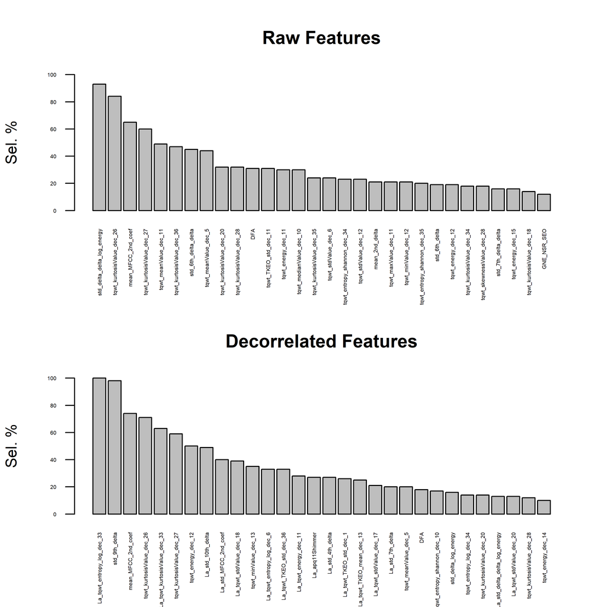

```r
par(mfrow=c(2,1),cex=0.9,cex.axis=0.8)

rawtopf <- cvRaw$featureFrequency/repetitions
crawtopf <- rawtopf

if (length(rawtopf) > 30)
{
  rawtopf <- rawtopf[1:30]
}
barplot(100*rawtopf,las=2,main="Raw Features",ylim=c(0,100.0),cex.names = 0.35,cex.axis = 0.35,ylab="Sel. %")

detopf <- cvDe$featureFrequency/repetitions
cdetopf <- detopf
names(cdetopf) <- str_remove_all(names(cdetopf),"Ba_")
names(cdetopf) <- str_remove_all(names(cdetopf),"La_")
if (length(detopf) > 30)
{
  detopf <- detopf[1:30]
}

barplot(100*detopf,las=2,main="Decorrelated Features",ylim=c(0,100.0),cex.names = 0.35,cex.axis = 0.35,ylab="Sel. %")
```

```r
par(op)
```

### 1.6.1 Final Table

```r
unlistdecorr <- selectedlist
names(unlistdecorr) <- NULL
unlistdecorr <- unique(names(unlist(unlistdecorr)))

finalTableDe <- univarDe$orderframe[deNames_in_dc,univariate_columns]

finalTableOr <- univar$orderframe[unique(c(topfiveOrg,unlistdecorr,names(crawtopf)[1:2],names(cdetopf)[1:2])),univariate_columns]

finalTable <- rbind(finalTableOr,finalTableDe)

deFromula <- character(length(theDeFormulas))
names(deFromula) <- names(theDeFormulas)

for (dx in names(deFromula))
{
  coef <- theDeFormulas[[dx]]
  cname <- names(theDeFormulas[[dx]])
  names(cname) <- cname
  for (cf in names(coef))
  {
    if (cf != dx)
    {
      if (coef[cf]>0)
      {
        deFromula[dx] <- paste(deFromula[dx],
                               sprintf("+ %5.3f*%s",coef[cf],cname[cf]))
      }
      else
      {
        deFromula[dx] <- paste(deFromula[dx],
                               sprintf("%5.3f*%s",coef[cf],cname[cf]))
      }
    }
  }
}

orgnamez <- rownames(finalTable)
orgnamez <- str_remove_all(orgnamez,"Ba_")
orgnamez <- str_remove_all(orgnamez,"La_")
finalTable$uAUC <- univar$orderframe[orgnamez,"ROCAUC"]
finalTable$raw_Freq <- crawtopf[orgnamez]
finalTable$La_Freq <- cdetopf[orgnamez]
finalTable$DecorFormula <- deFromula[rownames(finalTable)]
fscores <- attr(DEdataframe,"fscore")
finalTable$fscores <- fscores[rownames(finalTable)]

finalTable <- finalTable[order(-finalTable$ROCAUC),]

pander::pander(finalTable)
```

|  | caseMean | caseStd | controlMean | controlStd | controlKSP | ROCAUC | WilcoxRes.p | FRes.p | uAUC | raw_Freq | La_Freq | DecorFormula | fscores |
| --- | --- | --- | --- | --- | --- | --- | --- | --- | --- | --- | --- | --- | --- |
| **std_delta_delta_log_energy** | 1.56e-02 | 8.19e-03 | 8.83e-03 | 4.35e-03 | 1.52e-01 | 0.798 | 2.93e-11 | 4.44e-16 | 0.798 | 0.93 | 0.13 | NA | NA |
| **std_delta_log_energy** | 4.20e-02 | 2.76e-02 | 2.43e-02 | 1.23e-02 | 1.73e-01 | 0.794 | 5.93e-11 | 2.89e-15 | 0.794 | 0.01 | 0.16 | NA | 4 |
| **La_tqwt_entropy_log_dec_33** | -2.53e+02 | 2.32e+02 | 6.61e+01 | 3.72e+02 | 5.55e-01 | 0.792 | 9.17e-16 | 0.00e+00 | 0.644 | 0.02 | 1.00 | -0.693*tqwt_entropy_log_dec_31 + 1.000*tqwt_entropy_log_dec_33 | -1 |
| **std_9th_delta_delta** | 1.89e-02 | 4.69e-03 | 1.46e-02 | 2.48e-03 | 4.48e-01 | 0.787 | 1.72e-10 | 1.26e-13 | 0.787 | 0.11 | NA | NA | NA |
| **std_8th_delta_delta** | 1.94e-02 | 4.73e-03 | 1.51e-02 | 2.23e-03 | 9.08e-01 | 0.780 | 1.39e-09 | 2.39e-12 | 0.780 | 0.10 | NA | NA | NA |
| **std_7th_delta_delta** | 2.10e-02 | 5.62e-03 | 1.60e-02 | 2.94e-03 | 8.30e-01 | 0.776 | 4.53e-10 | 1.26e-12 | 0.776 | 0.16 | NA | NA | NA |
| **tqwt_entropy_log_dec_12** | -1.68e+05 | 3.86e+04 | -1.32e+05 | 3.25e+04 | 3.62e-01 | 0.770 | 3.44e-11 | 3.09e-13 | 0.770 | 0.02 | 0.01 | NA | NA |
| **std_8th_delta** | 4.09e-02 | 1.02e-02 | 3.20e-02 | 5.14e-03 | 9.60e-01 | 0.767 | 1.08e-08 | 1.04e-11 | 0.767 | 0.03 | 0.02 | NA | NA |
| **std_9th_delta** | 3.94e-02 | 1.01e-02 | 3.08e-02 | 5.80e-03 | 1.17e-01 | 0.764 | 7.85e-09 | 9.93e-12 | 0.764 | 0.03 | 0.98 | NA | 3 |
| **tqwt_entropy_shannon_dec_12** | 6.13e+01 | 1.43e+02 | 2.18e+02 | 2.52e+02 | 1.36e-02 | 0.763 | 7.98e-17 | 3.78e-11 | 0.763 | 0.01 | NA | NA | NA |
| **tqwt_stdValue_dec_12** | 1.81e-02 | 2.10e-02 | 4.45e-02 | 3.45e-02 | 2.92e-01 | 0.763 | 9.69e-16 | 3.45e-13 | 0.763 | 0.23 | 0.01 | NA | NA |
| **std_7th_delta** | 4.41e-02 | 1.21e-02 | 3.41e-02 | 6.99e-03 | 7.49e-01 | 0.760 | 4.85e-09 | 1.88e-11 | 0.760 | 0.06 | 0.20 | NA | NA |
| **tqwt_entropy_log_dec_11** | -2.21e+05 | 4.22e+04 | -1.86e+05 | 3.69e+04 | 3.21e-01 | 0.754 | 9.01e-10 | 3.73e-11 | 0.754 | NA | 0.03 | NA | NA |
| **tqwt_TKEO_mean_dec_13** | 5.74e-03 | 1.91e-02 | 1.77e-02 | 2.51e-02 | 9.85e-04 | 0.753 | 1.92e-16 | 7.27e-07 | 0.753 | NA | 0.25 | NA | NA |
| **tqwt_minValue_dec_12** | -9.07e-02 | 6.74e-02 | -1.77e-01 | 1.08e-01 | 4.04e-01 | 0.752 | 1.48e-13 | 2.49e-13 | 0.752 | 0.21 | 0.05 | NA | NA |
| **std_6th_delta** | 4.75e-02 | 1.36e-02 | 3.66e-02 | 6.86e-03 | 3.36e-01 | 0.749 | 2.69e-08 | 2.35e-10 | 0.749 | 0.19 | NA | NA | NA |
| **La_tqwt_kurtosisValue_dec_33** | 2.42e+00 | 3.33e+00 | -3.33e-01 | 4.52e+00 | 9.49e-03 | 0.749 | 3.03e-10 | 1.10e-11 | 0.628 | NA | 0.63 | -0.872*tqwt_kurtosisValue_dec_32 + 1.000*tqwt_kurtosisValue_dec_33 | -1 |
| **std_10th_delta** | 3.89e-02 | 1.05e-02 | 3.07e-02 | 5.57e-03 | 8.51e-01 | 0.746 | 4.51e-08 | 1.07e-09 | 0.746 | NA | 0.49 | NA | NA |
| **tqwt_minValue_dec_13** | -1.60e-01 | 1.26e-01 | -2.92e-01 | 1.68e-01 | 6.80e-01 | 0.746 | 1.11e-12 | 8.76e-11 | 0.746 | 0.01 | 0.35 | NA | 4 |
| **La_std_delta_delta_log_energy** | 3.48e-03 | 3.09e-03 | 1.84e-03 | 1.64e-03 | 8.73e-02 | 0.744 | 1.99e-07 | 2.28e-06 | 0.798 | 0.93 | 0.13 | -0.288*std_delta_log_energy + 1.000*std_delta_delta_log_energy | -1 |
| **tqwt_entropy_shannon_dec_11** | 2.52e+01 | 4.42e+01 | 8.76e+01 | 1.07e+02 | 2.71e-03 | 0.744 | 1.64e-14 | 7.60e-11 | 0.744 | 0.02 | 0.02 | NA | NA |
| **tqwt_TKEO_std_dec_11** | 4.46e-04 | 7.61e-04 | 1.84e-03 | 2.70e-03 | 5.42e-04 | 0.741 | 5.12e-15 | 9.27e-12 | 0.741 | 0.31 | 0.06 | NA | NA |
| **std_12th_delta** | 3.46e-02 | 8.43e-03 | 2.85e-02 | 5.98e-03 | 7.23e-02 | 0.734 | 2.74e-07 | 8.71e-09 | 0.734 | NA | 0.03 | NA | NA |
| **La_apq11Shimmer** | 1.38e-02 | 1.45e-02 | 4.49e-03 | 9.78e-03 | 3.25e-02 | 0.731 | 4.41e-07 | 6.24e-08 | 0.713 | NA | 0.27 | -1.278*apq3Shimmer + 1.000*apq11Shimmer | -1 |
| **tqwt_TKEO_mean_dec_11** | 2.93e-04 | 6.22e-04 | 1.19e-03 | 1.99e-03 | 8.06e-05 | 0.731 | 2.01e-14 | 7.40e-09 | 0.731 | 0.07 | NA | NA | NA |
| **La_std_6th_delta** | 9.37e-03 | 7.37e-03 | 5.06e-03 | 3.64e-03 | 7.46e-01 | 0.726 | 2.39e-07 | 3.34e-05 | 0.749 | 0.19 | NA | -0.106*std_MFCC_6th_coef + 1.000*std_6th_delta | 0 |
| **tqwt_TKEO_std_dec_14** | 1.49e-02 | 2.25e-02 | 3.41e-02 | 3.25e-02 | 4.85e-02 | 0.723 | 1.05e-11 | 2.23e-07 | 0.723 | 0.01 | 0.01 | NA | NA |
| **tqwt_entropy_log_dec_14** | -8.08e+04 | 2.54e+04 | -6.34e+04 | 1.80e+04 | 2.28e-01 | 0.720 | 1.10e-06 | 3.29e-08 | 0.720 | NA | NA | NA | NA |
| **La_tqwt_entropy_shannon_dec_33** | -5.89e-01 | 1.60e+00 | 6.74e-01 | 3.68e+00 | 3.36e-06 | 0.720 | 7.00e-07 | 4.49e-06 | 0.379 | 0.01 | 0.08 | -0.725*tqwt_entropy_shannon_dec_32 + 1.000*tqwt_entropy_shannon_dec_33 | 0 |
| **tqwt_entropy_shannon_dec_14** | 3.39e+02 | 3.73e+02 | 6.62e+02 | 4.76e+02 | 6.14e-01 | 0.718 | 2.77e-09 | 6.36e-08 | 0.718 | NA | NA | NA | NA |

[output cut: 122 more lines]